# EDA - Beach Volleyball (vb_matches.csv)

Nicolle Ramírez y Roger Daza

2026-08-28

# 1 Bloque 1 — Importación, estructura y limpieza inicial

## 1.1 Carga y estructura general

```r
df <- read_csv("vb_matches.csv")

str(df)
```

```
## spc_tbl_ [76,756 × 65] (S3: spec_tbl_df/tbl_df/tbl/data.frame)
##  $ circuit              : chr [1:76756] "AVP" "AVP" "AVP" "AVP" ...
##  $ tournament           : chr [1:76756] "Huntington Beach" "Huntington Beach" "Huntington Beach" "Huntington Beach" ...
##  $ country              : chr [1:76756] "United States" "United States" "United States" "United States" ...
##  $ year                 : num [1:76756] 2002 2002 2002 2002 2002 ...
##  $ date                 : Date[1:76756], format: "2002-05-24" "2002-05-24" ...
##  $ gender               : chr [1:76756] "M" "M" "M" "M" ...
##  $ match_num            : num [1:76756] 1 2 3 4 5 6 7 8 9 10 ...
##  $ w_player1            : chr [1:76756] "Kevin Wong" "Brad Torsone" "Eduardo Bacil" "Brent Doble" ...
##  $ w_p1_birthdate       : Date[1:76756], format: "1972-09-12" "1975-01-14" ...
##  $ w_p1_age             : num [1:76756] 29.7 27.4 31.2 32.4 32.1 ...
##  $ w_p1_hgt             : num [1:76756] 79 78 74 78 75 75 78 77 75 79 ...
##  $ w_p1_country         : chr [1:76756] "United States" "United States" "Brazil" "United States" ...
##  $ w_player2            : chr [1:76756] "Stein Metzger" "Casey Jennings" "Fred Souza" "Karch Kiraly" ...
##  $ w_p2_birthdate       : Date[1:76756], format: "1972-11-17" "1975-07-10" ...
##  $ w_p2_age             : num [1:76756] 29.5 26.9 30 41.6 29.8 ...
##  $ w_p2_hgt             : num [1:76756] 75 75 79 74 80 77 78 79 75 76 ...
##  $ w_p2_country         : chr [1:76756] "United States" "United States" "Brazil" "United States" ...
##  $ w_rank               : chr [1:76756] "1" "16" "24" "8" ...
##  $ l_player1            : chr [1:76756] "Chuck Moore" "Mark Paaluhi" "Adam Jewell" "David Swatik" ...
##  $ l_p1_birthdate       : Date[1:76756], format: "1973-08-18" "1971-03-08" ...
##  $ l_p1_age             : num [1:76756] 28.8 31.2 26.9 29.3 26.3 ...
##  $ l_p1_hgt             : num [1:76756] 76 75 77 76 73 NA 75 75 68 75 ...
##  $ l_p1_country         : chr [1:76756] "United States" "United States" "United States" "United States" ...
##  $ l_player2            : chr [1:76756] "Ed Ratledge" "Nick Hannemann" "Collin Smith" "Mike Mattarocci" ...
##  $ l_p2_birthdate       : Date[1:76756], format: "1976-12-16" "1972-01-12" ...
##  $ l_p2_age             : num [1:76756] 25.4 30.4 27 32.6 24.2 ...
##  $ l_p2_hgt             : num [1:76756] 80 78 76 80 75 76 81 77 77 74 ...
##  $ l_p2_country         : chr [1:76756] "United States" "United States" "United States" "United States" ...
##  $ l_rank               : chr [1:76756] "32" "17" "9" "25" ...
##  $ score                : chr [1:76756] "21-18, 21-12" "21-16, 17-21, 15-10" "21-18, 21-18" "21-16, 21-15" ...
##  $ duration             : 'hms' num [1:76756] 00:33:00 00:57:00 00:46:00 00:44:00 ...
##   ..- attr(*, "units")= chr "secs"
##  $ bracket              : chr [1:76756] "Winner's Bracket" "Winner's Bracket" "Winner's Bracket" "Winner's Bracket" ...
##  $ round                : chr [1:76756] "Round 1" "Round 1" "Round 1" "Round 1" ...
##  $ w_p1_tot_attacks     : num [1:76756] NA NA NA NA NA NA NA NA NA NA ...
##  $ w_p1_tot_kills       : num [1:76756] NA NA NA NA NA NA NA NA NA NA ...
##  $ w_p1_tot_errors      : num [1:76756] NA NA NA NA NA NA NA NA NA NA ...
##  $ w_p1_tot_hitpct      : num [1:76756] NA NA NA NA NA NA NA NA NA NA ...
##  $ w_p1_tot_aces        : num [1:76756] 1 0 0 0 1 0 0 0 1 2 ...
```

[output cut: 81 more lines]

```
##   ..   l_p1_tot_hitpct = col_double(),
##   ..   l_p1_tot_aces = col_double(),
##   ..   l_p1_tot_serve_errors = col_double(),
##   ..   l_p1_tot_blocks = col_double(),
##   ..   l_p1_tot_digs = col_double(),
##   ..   l_p2_tot_attacks = col_double(),
##   ..   l_p2_tot_kills = col_double(),
##   ..   l_p2_tot_errors = col_double(),
##   ..   l_p2_tot_hitpct = col_double(),
##   ..   l_p2_tot_aces = col_double(),
##   ..   l_p2_tot_serve_errors = col_double(),
##   ..   l_p2_tot_blocks = col_double(),
##   ..   l_p2_tot_digs = col_double()
##   .. )
##  - attr(*, "problems")=<externalptr>
```

```r
datatable(head(df, 10),
          options = list(scrollX = TRUE, pageLength = 5),
          caption = "Primeras 10 filas del dataset")
```

|  | circuit | tournament | country | year | date | gender | match_num | w_player1 | w_p1_birthdate | w_p1_age | w_p1_hgt | w_p1_country | w_player2 | w_p2_birthdate | w_p2_age | w_p2_hgt | w_p2_country | w_rank | l_player1 | l_p1_birthdate | l_p1_age | l_p1_hgt | l_p1_country | l_player2 | l_p2_birthdate | l_p2_age | l_p2_hgt | l_p2_country | l_rank | … |
| --- | --- | --- | --- | --- | --- | --- | --- | --- | --- | --- | --- | --- | --- | --- | --- | --- | --- | --- | --- | --- | --- | --- | --- | --- | --- | --- | --- | --- | --- | --- |
| 1 | AVP | Huntington Beach | United States | 2002 | 2002-05-24 | M | 1 | Kevin Wong | 1972-09-12 | 29.6947296 | 79 | United States | Stein Metzger | 1972-11-17 | 29.5140315 | 75 | United States | 1 | Chuck Moore | 1973-08-18 | 28.7638604 | 76 | United States | Ed Ratledge | 1976-12-16 | 25.4346338 | 80 | United States | 32 | … |
| 2 | AVP | Huntington Beach | United States | 2002 | 2002-05-24 | M | 2 | Brad Torsone | 1975-01-14 | 27.3566051 | 78 | United States | Casey Jennings | 1975-07-10 | 26.8720055 | 75 | United States | 16 | Mark Paaluhi | 1971-03-08 | 31.211499 | 75 | United States | Nick Hannemann | 1972-01-12 | 30.3627652 | 78 | United States | 17 | … |
| 3 | AVP | Huntington Beach | United States | 2002 | 2002-05-24 | M | 3 | Eduardo Bacil | 1971-03-11 | 31.2032854 | 74 | Brazil | Fred Souza | 1972-05-13 | 30.0287474 | 79 | Brazil | 24 | Adam Jewell | 1975-06-24 | 26.9158111 | 77 | United States | Collin Smith | 1975-05-26 | 26.9952088 | 76 | United States | 9 | … |
| 4 | AVP | Huntington Beach | United States | 2002 | 2002-05-24 | M | 4 | Brent Doble | 1970-01-03 | 32.386037 | 78 | United States | Karch Kiraly | 2060-11-03 | 41.5523614 | 74 | United States | 8 | David Swatik | 1973-02-14 | 29.2703628 | 76 | United States | Mike Mattarocci | 1969-10-05 | 32.6324435 | 80 | United States | 25 | … |
| 5 | AVP | Huntington Beach | United States | 2002 | 2002-05-24 | M | 5 | Albert Hannemann | 1970-05-04 | 32.054757 | 75 | United States | Jeff Nygaard | 1972-08-03 | 29.8042437 | 80 | United States | 5 | Adam Roberts | 1976-01-25 | 26.3271732 | 73 | United States | Jim Walls | 1978-03-26 | 24.1615332 | 75 | United States | 28 | … |
| 6 | AVP | Huntington Beach | United States | 2002 | 2002-05-24 | M | 6 | Jason Ring | 1974-07-21 | 27.8412047 | 75 | United States | Paul Baxter | 1972-02-01 | 30.3080082 | 77 | United States | 12 | Eli Fairfield | 1979-02-10 | 23.2826831 |  | United States | Juan Rodriguez Ibarra | 1969-05-30 | 32.9828884 | 76 | Mexico | 21 | … |
| 7 | AVP | Huntington Beach | United States | 2002 | 2002-05-24 | M | 7 | Aaron Boss | 1970-11-30 | 31.4798084 | 78 | United States | Scott Lane | 1974-02-21 | 28.2518823 | 78 | United States | 13 | David Smith | 1972-02-26 | 30.2395619 | 75 | United States | Leland Quinn | 1972-04-03 | 30.1382615 | 81 | United States | 20 | … |
| 8 | AVP | Huntington Beach | United States | 2002 | 2002-05-24 | M | 8 | Canyon Ceman | 1972-06-21 | 29.9219713 | 77 | United States | Mike Whitmarsh |  |  | 79 | United States | 4 | Chris Makos | 1973-04-21 | 29.0896646 | 75 | United States | Scott Wong | 1978-12-31 | 23.394935 | 77 | United States | 29 | … |
| 9 | AVP | Huntington Beach | United States | 2002 | 2002-05-24 | M | 9 | Dax Holdren | 1972-09-04 | 29.7166324 | 75 | United States | Eric Fonoimoana | 1969-06-07 | 32.9609856 | 75 | United States | 3 | Evan Silberstein | 1975-10-13 | 26.6119097 | 68 | United States | Jim Van Zwieten | 1977-09-25 | 24.659822 | 77 | United States | 30 | … |
| 10 | AVP | Huntington Beach | United States | 2002 | 2002-05-24 | M | 10 | Mark Williams | 1979-01-27 | 23.321013 | 79 | Australia | Sean Rosenthal | 1980-06-19 | 21.927447 | 76 | United States | 14 | David Fischer | 1972-04-09 | 30.1218344 | 75 | United States | Jerry Graham | 1971-04-02 | 31.1430527 | 74 | United States | 19 | … |

El dataset tiene **76756 partidos** y **65 columnas**, tal como describe el plan de desarrollo (76.756 filas, 65 columnas).

## 1.2 Conversión de tipos

```r
# Variables categóricas
df <- df %>%
  mutate(across(c(circuit, gender, country, bracket, round,
                   w_p1_country, w_p2_country, l_p1_country, l_p2_country),
                as.factor))

# Fechas: en el CSV ya vienen en formato YYYY-MM-DD
df <- df %>%
  mutate(
    date           = as.Date(as.character(date), format = "%Y-%m-%d"),
    w_p1_birthdate = as.Date(as.character(w_p1_birthdate), format = "%Y-%m-%d"),
    w_p2_birthdate = as.Date(as.character(w_p2_birthdate), format = "%Y-%m-%d"),
    l_p1_birthdate = as.Date(as.character(l_p1_birthdate), format = "%Y-%m-%d"),
    l_p2_birthdate = as.Date(as.character(l_p2_birthdate), format = "%Y-%m-%d")
  )

summary(df$date)
```

```
##         Min.      1st Qu.       Median         Mean      3rd Qu.         Max.
## "2000-09-16" "2006-05-31" "2009-08-25" "2010-10-18" "2015-10-07" "2019-08-29"
```

### 1.2.1 Decisión de limpieza: `w_rank` y `l_rank`

Se separa el ranking numérico de la anotación de qualifier en dos columnas nuevas, dejando el ranking limpio disponible para los bloques de outliers, univariado y comparativo:

```r
df <- df %>%
  separate(w_rank, into = c("w_rank_num", "w_rank_qual"),
           sep = ",", extra = "merge", fill = "right", remove = FALSE) %>%
  separate(l_rank, into = c("l_rank_num", "l_rank_qual"),
           sep = ",", extra = "merge", fill = "right", remove = FALSE) %>%
  mutate(
    w_rank_num = as.numeric(trimws(w_rank_num)),
    l_rank_num = as.numeric(trimws(l_rank_num)),
    w_rank_qual = trimws(w_rank_qual),
    l_rank_qual = trimws(l_rank_qual)
  )

cat("Partidos con w_rank proveniente de qualifiers:", sum(!is.na(df$w_rank_qual)), "\n")
```

```
## Partidos con w_rank proveniente de qualifiers: 18324
```

```r
summary(df$w_rank_num)
```

```
##    Min. 1st Qu.  Median    Mean 3rd Qu.    Max.    NA's
##    1.00    5.00   12.00   13.41   21.00   64.00   11887
```

## 1.3 Duplicados

```r
sum(duplicated(df))
```

```
## [1] 0
```

No hay filas duplicadas en el dataset (0 de 76756).

## 1.4 Exploración de `score` (opcional)

```r
df %>%
  select(score) %>%
  head(5) %>%
  separate(score, into = c("set1", "set2", "set3"),
           sep = ",\\s*", fill = "right") %>%
  datatable(options = list(dom = "t"),
            caption = "Marcador partido en sets individuales (ejemplo)")
```

|  | set1 | set2 | set3 |
| --- | --- | --- | --- |
| 1 | 21-18 | 21-12 |  |
| 2 | 21-16 | 17-21 | 15-10 |
| 3 | 21-18 | 21-18 |  |
| 4 | 21-16 | 21-15 |  |
| 5 | 20-22 | 23-21 | 15-10 |

El marcador viene como texto tipo `"21-18, 21-12"`: uno o más sets separados por coma, cada set con el formato `puntos_ganador-puntos_perdedor`. Se deja identificado aquí; partir cada set en sus dos puntajes numéricos se retoma más adelante solo si algún bloque lo necesita (no está entre los obligatorios del plan).

## 1.5 Resumen de decisiones de limpieza (Bloque 1)

- Se convirtieron a `factor` las variables categóricas: `circuit`, `gender`, `country`, `bracket`, `round` y los `*_country` de cada jugador.
- Se convirtieron a `Date` las columnas `date` y las cuatro `*_birthdate` (formato `YYYY-MM-DD`, ya venían así en el CSV).
- `w_rank`/`l_rank` **no** se convirtieron a factor: contienen texto mixto (`"17, Q2"`) porque algunos partidos vienen de rondas de qualifiers. Se crearon `w_rank_num`/`l_rank_num` (numéricos, listos para análisis) y `w_rank_qual`/`l_rank_qual` (texto, para no perder esa información).
- No se encontraron filas duplicadas.
- `score` se deja como texto por ahora; se revisará más adelante si algún bloque lo necesita separado en sets.

# 2 Bloque 2 — Análisis de valores faltantes

## 2.1 Porcentaje de NA por columna

```r
na_resumen <- df %>%
  summarise(across(everything(), ~ mean(is.na(.)) * 100)) %>%
  pivot_longer(cols = everything(), names_to = "variable", values_to = "pct_na") %>%
  filter(pct_na > 0) %>%
  arrange(desc(pct_na))

datatable(na_resumen %>% mutate(pct_na = round(pct_na, 2)),
          options = list(pageLength = 10, order = list(list(1, "desc"))),
          caption = "Porcentaje de valores faltantes por columna (solo columnas con NA)")
```

|  | variable | pct_na |
| --- | --- | --- |
| 1 | l_rank_qual | 82.54 |
| 2 | l_p1_tot_serve_errors | 81.32 |
| 3 | w_p1_tot_serve_errors | 81.32 |
| 4 | l_p2_tot_serve_errors | 81.32 |
| 5 | w_p1_tot_errors | 81.31 |
| 6 | w_p2_tot_errors | 81.31 |
| 7 | w_p2_tot_serve_errors | 81.31 |
| 8 | l_p1_tot_errors | 81.31 |
| 9 | l_p2_tot_errors | 81.31 |
| 10 | l_p1_tot_hitpct | 81.02 |

[output cut: 47 more lines]

```r
p_na <- na_resumen %>%
  slice_max(pct_na, n = 20) %>%
  mutate(variable = reorder(variable, pct_na)) %>%
  ggplot(aes(x = variable, y = pct_na)) +
  geom_col(fill = "steelblue") +
  coord_flip() +
  labs(title = "Top 20 variables con más valores faltantes",
       subtitle = "vb_matches.csv — el resto de variables con NA está en la tabla de arriba",
       x = NULL, y = "% de valores faltantes") +
  theme(axis.text.y = element_text(size = 10))

ggplotly(p_na, tooltip = c("x", "y"))
```

[interactive chart not shown]

## 2.2 ¿Por qué faltan las estadísticas de juego? Relación con el circuito

```r
na_circuito <- df %>%
  group_by(year, circuit) %>%
  summarise(pct_na_kills = mean(is.na(w_p1_tot_kills)) * 100, .groups = "drop")

p_circuito <- na_circuito %>%
  ggplot(aes(x = year, y = pct_na_kills, color = circuit)) +
  geom_point(size = 2) +
  geom_line() +
  scale_color_manual(values = c("FIVB" = "#d95f02", "AVP" = "#1b9e77")) +
  labs(title = "% de valores faltantes en estadísticas de juego (kills) por año",
       subtitle = "Comparación entre circuitos FIVB y AVP, 2000-2019",
       x = "Año", y = "% de NA en w_p1_tot_kills", color = "Circuito")

ggplotly(p_circuito)
```

[interactive chart not shown]

Este gráfico es clave: el faltante **no es aleatorio (no es MCAR)**. FIVB prácticamente nunca reporta estadísticas de juego (cercano al 100% de NA casi todos los años), mientras que AVP sí las reporta con más frecuencia (entre 40% y 88% de NA según el año, con tendencia a mejorar después de 2010). Esto quiere decir que el faltante depende de una variable observada (`circuit`), lo cual clasifica más como **MAR (missing at random condicionado)** que como MCAR puro. La consecuencia práctica es que cualquier análisis del dashboard que use estadísticas de juego (kills, aces, bloqueos, digs) va a estar representando casi exclusivamente partidos de AVP, y eso hay que dejarlo explícito para no generalizar resultados de AVP como si fueran del deporte completo.

## 2.3 NA en ranking y datos físicos

```r
df %>%
  summarise(
    w_rank_na = mean(is.na(w_rank_num)) * 100,
    l_rank_na = mean(is.na(l_rank_num)) * 100,
    w_p1_hgt_na = mean(is.na(w_p1_hgt)) * 100,
    l_p1_hgt_na = mean(is.na(l_p1_hgt)) * 100,
    w_p1_age_na = mean(is.na(w_p1_age)) * 100,
    l_p1_age_na = mean(is.na(l_p1_age)) * 100
  ) %>%
  pivot_longer(everything(), names_to = "variable", values_to = "pct_na") %>%
  mutate(pct_na = round(pct_na, 2)) %>%
  datatable(options = list(dom = "t"),
            caption = "% de NA en ranking, estatura y edad")
```

|  | variable | pct_na |
| --- | --- | --- |
| 1 | w_rank_na | 15.49 |
| 2 | l_rank_na | 30.38 |
| 3 | w_p1_hgt_na | 5.17 |
| 4 | l_p1_hgt_na | 9.1 |
| 5 | w_p1_age_na | 0.5 |
| 6 | l_p1_age_na | 1.38 |

`w_rank_num`/`l_rank_num` tienen un NA más alto de lo que parecía a primera vista: **15.49% y 30.38%** respectivamente. La razón es que al convertir a numérico con `as.numeric()`, los casos que venían solo como `"Q65"` (sin ranking principal, solo posición de clasificatorio, sin coma) no se pueden convertir y quedan como `NA` — son 11.739 casos adicionales que no estaban contados si uno mira solo el NA del texto original (`w_rank`/`l_rank`, que sí es bajo: 0.19% y 1.62%). La edad se mantiene con NA bajo (<1.4% en todos los casos). La estatura es la que más pesa proporcionalmente entre las “bajas”, sobre todo la de los perdedores (9%), pero el ranking del perdedor (`l_rank_num`, 30.38%) es en realidad la variable con más NA después de las estadísticas de juego.

## 2.4 Plan de tratamiento por variable

# 3 Bloque 3 — Variables categóricas

## 3.1 Circuito y género

```r
p_circuit <- df %>%
  count(circuit) %>%
  mutate(Porcentaje = (n / sum(n)) * 100) %>%
  ggplot(aes(x = circuit, y = n, fill = circuit)) +
  geom_col() +
  geom_text(aes(label = paste0(n, " (", round(Porcentaje, 1), "%)")),
            vjust = -0.5, size = 4) +
  scale_fill_manual(values = c("FIVB" = "#d95f02", "AVP" = "#1b9e77")) +
  labs(title = "Partidos por circuito", x = "Circuito", y = "Número de partidos") +
  theme(legend.position = "none")

ggplotly(p_circuit, tooltip = c("x", "y"))
```

[interactive chart not shown]

```r
p_gender <- df %>%
  count(gender) %>%
  mutate(Porcentaje = (n / sum(n)) * 100) %>%
  ggplot(aes(x = gender, y = n, fill = gender)) +
  geom_col() +
  geom_text(aes(label = paste0(n, " (", round(Porcentaje, 1), "%)")),
            vjust = -0.5, size = 4) +
  labs(title = "Partidos por género", x = "Género", y = "Número de partidos") +
  theme(legend.position = "none")

ggplotly(p_gender, tooltip = c("x", "y"))
```

[interactive chart not shown]

`FIVB` concentra el 66.97% de los partidos (51.403) frente a 33.03% de `AVP` (25.353) — dos a uno, tal como indica el plan. El género está bastante balanceado: 52.46% masculino (40.270) contra 47.54% femenino (36.486), no hay un desbalance relevante ahí.

## 3.2 Países: sede de torneo y procedencia de jugadores

```r
top_sede <- df %>% count(country, sort = TRUE) %>% slice_head(n = 10)

datatable(top_sede, options = list(dom = "t"),
          caption = "Top 10 países sede de torneo")
```

|  | country | n |
| --- | --- | --- |
| 1 | United States | 27311 |
| 2 | China | 6158 |
| 3 | Switzerland | 4116 |
| 4 | Poland | 3358 |
| 5 | Russia | 3318 |
| 6 | Austria | 3302 |
| 7 | Norway | 3280 |
| 8 | France | 2567 |
| 9 | Germany | 2297 |
| 10 | Brazil | 2070 |

```r
top_sede %>%
  mutate(country = reorder(country, n)) %>%
  ggplot(aes(x = country, y = n)) +
  geom_col(fill = "steelblue") +
  coord_flip() +
  labs(title = "Top 10 países sede de torneo", x = NULL, y = "Número de partidos") -> p_sede

ggplotly(p_sede, tooltip = c("x", "y"))
```

[interactive chart not shown]

```r
top_jugadores <- bind_rows(
  df %>% select(country = w_p1_country),
  df %>% select(country = w_p2_country),
  df %>% select(country = l_p1_country),
  df %>% select(country = l_p2_country)
) %>%
  count(country, sort = TRUE) %>%
  slice_head(n = 15)

datatable(top_jugadores, options = list(dom = "t"),
          caption = "Top 15 países de procedencia de jugadores (las 4 posiciones combinadas)")
```

|  | country | n |
| --- | --- | --- |
| 1 | United States | 112538 |
| 2 | Brazil | 25162 |
| 3 | Germany | 16666 |
| 4 | Switzerland | 9930 |
| 5 | Canada | 9597 |
| 6 | Austria | 9302 |
| 7 | Netherlands | 9000 |
| 8 | Russia | 8283 |
| 9 | China | 7874 |
| 10 | Italy | 7780 |

[output cut: 5 more lines]

Estados Unidos domina ambos rankings — es sede de 27.311 partidos (muy por encima de China, segundo con 6.158) y también el país de procedencia de más jugadores (112.538 registros entre las 4 posiciones), lo cual tiene sentido porque ahí vive todo el circuito AVP además de la parte estadounidense de FIVB. Brasil es un claro segundo en jugadores (25.162), coherente con su tradición en el voleibol de playa, aunque como sede está más abajo (2.070).

## 3.3 Recategorización de `bracket`

`bracket` tiene 36 categorías, la mayoría con muy pocos partidos (varias `Pool` con menos de 50 registros). Se agrupan en 3 categorías más manejables para el dashboard:

```r
df <- df %>%
  mutate(bracket_group = case_when(
    bracket %in% c("Qualifier Bracket", "Qualifier Playoff", "Lucky Losers",
                   "Country Quota Matches") ~ "Fase de clasificación",
    grepl("^Pool", bracket) ~ "Fase de grupos (Pool play)",
    TRUE ~ "Bracket eliminatorio / Finales"
  ))

datatable(
  df %>% count(bracket_group, sort = TRUE) %>%
    mutate(Porcentaje = round(n / sum(n) * 100, 1)),
  options = list(dom = "t"),
  caption = "Partidos por bracket_group (recategorizado)"
)
```

|  | bracket_group | n | Porcentaje |
| --- | --- | --- | --- |
| 1 | Bracket eliminatorio / Finales | 36003 | 46.9 |
| 2 | Fase de clasificación | 23593 | 30.7 |
| 3 | Fase de grupos (Pool play) | 17160 | 22.4 |

```r
p_bracket <- df %>%
  count(bracket_group) %>%
  mutate(bracket_group = reorder(bracket_group, n)) %>%
  ggplot(aes(x = bracket_group, y = n, fill = bracket_group)) +
  geom_col() +
  coord_flip() +
  labs(title = "Partidos por fase del torneo (bracket recategorizado)",
       x = NULL, y = "Número de partidos") +
  theme(legend.position = "none")

ggplotly(p_bracket, tooltip = c("x", "y"))
```

[interactive chart not shown]

# 4 Bloque 4 — Outliers

## 4.1 Duración del partido

```r
df <- df %>%
  separate(duration, into = c("dur_h", "dur_m", "dur_s"),
           sep = ":", remove = FALSE, convert = TRUE) %>%
  mutate(duration_min = dur_h * 60 + dur_m + dur_s / 60) %>%
  select(-dur_h, -dur_m, -dur_s)

summary(df$duration_min)
```

```
##    Min. 1st Qu.  Median    Mean 3rd Qu.    Max.    NA's
##    2.00   36.00   42.00   43.92   51.00  134.00    2249
```

```r
p_dur_box <- df %>%
  ggplot(aes(x = "", y = duration_min)) +
  geom_boxplot(fill = "steelblue", outlier.color = "firebrick", outlier.alpha = 0.4) +
  labs(title = "Duración del partido (minutos)",
       subtitle = "Boxplot con outliers según método IQR",
       x = NULL, y = "Minutos")

ggplotly(p_dur_box)
```

[interactive chart not shown]

Con el método IQR (Q1 - 1.5·IQR, Q3 + 1.5·IQR), el rango “normal” de duración queda entre **13.5 y 73.5 minutos**. Fuera de ahí hay **902 partidos (1.21%)** marcados como outliers, con un mínimo de 2 minutos (casi seguro un walkover o partido no completado) y un máximo de 134 minutos (2h 14min, probablemente un partido a tres sets muy reñido).

## 4.2 Estatura de los jugadores

```r
df_hgt_long <- bind_rows(
  df %>% transmute(hgt = w_p1_hgt, jugador = "w_p1"),
  df %>% transmute(hgt = w_p2_hgt, jugador = "w_p2")
)

p_hgt_box <- df_hgt_long %>%
  ggplot(aes(x = jugador, y = hgt, fill = jugador)) +
  geom_boxplot(outlier.color = "firebrick", outlier.alpha = 0.4) +
  labs(title = "Estatura de jugadores ganadores (posición 1 y 2)",
       subtitle = "Outliers según IQR marcados en rojo",
       x = NULL, y = "Estatura (pulgadas)") +
  theme(legend.position = "none")

ggplotly(p_hgt_box)
```

[interactive chart not shown]

La estatura tiene muy pocos outliers: **0.15%** en `w_p1_hgt` (109 de 72.790) y **0.36%** en `w_p2_hgt` (262 de 72.740), con rango normal entre 63.5 y 83.5 pulgadas (~1.61m a ~2.12m), coherente con lo esperado en voleibol de playa profesional.

## 4.3 Edad de los jugadores

```r
p_age_hist <- df %>%
  ggplot(aes(x = w_p1_age)) +
  geom_histogram(binwidth = 2, fill = "steelblue", color = "white") +
  geom_vline(xintercept = c(14.4, 42.6), linetype = "dashed", color = "firebrick") +
  labs(title = "Distribución de edad (w_p1_age)",
       subtitle = "Líneas punteadas = límites IQR (14.4 - 42.6 años)",
       x = "Edad", y = "Número de partidos")

ggplotly(p_age_hist)
```

[interactive chart not shown]

La edad tiene **0.86% de outliers** (656 de 76.373), con un mínimo de 13.5 años y un máximo de 59.9 años. El límite inferior del IQR (14.4) es muy cercano al mínimo real, así que la mayoría de esos outliers están concentrados en el extremo superior: jugadores veteranos jugando por encima de los ~43 años, algo poco común pero no imposible en el circuito.

## 4.4 Resumen de outliers (Bloque 4)

```r
tibble(
  variable = c("duration_min", "w_p1_age", "w_p1_hgt", "w_p2_hgt"),
  n_outliers = c(902, 656, 109, 262),
  pct_outliers = c(1.21, 0.86, 0.15, 0.36),
  rango_normal_IQR = c("13.5 - 73.5 min", "14.4 - 42.6 años",
                        "63.5 - 83.5 in", "63.5 - 83.5 in")
) %>%
  datatable(options = list(dom = "t"), caption = "Resumen de outliers por variable (método IQR)")
```

|  | variable | n_outliers | pct_outliers | rango_normal_IQR |
| --- | --- | --- | --- | --- |
| 1 | duration_min | 902 | 1.21 | 13.5 - 73.5 min |
| 2 | w_p1_age | 656 | 0.86 | 14.4 - 42.6 años |
| 3 | w_p1_hgt | 109 | 0.15 | 63.5 - 83.5 in |
| 4 | w_p2_hgt | 262 | 0.36 | 63.5 - 83.5 in |

En ningún caso el porcentaje de outliers supera el 1.3%, así que **no se eliminan** — son valores extremos legítimos (partidos muy cortos/largos, jugadores muy jóvenes/veteranos), no errores de captura de datos. Se dejan en el dataset y se documentan aquí para que el dashboard pueda, si se quiere, ofrecer un filtro opcional que los excluya.

# 5 Bloque 5 — Análisis univariado numérico

## 5.1 Estadísticos descriptivos

```r
resumen_num <- df %>%
  summarise(
    across(c(duration_min, w_p1_age, w_p1_hgt, w_p2_hgt),
           list(media = ~mean(., na.rm = TRUE),
                mediana = ~median(., na.rm = TRUE),
                sd = ~sd(., na.rm = TRUE),
                min = ~min(., na.rm = TRUE),
                max = ~max(., na.rm = TRUE),
                p25 = ~quantile(., .25, na.rm = TRUE),
                p75 = ~quantile(., .75, na.rm = TRUE)),
           .names = "{.col}__{.fn}")
  ) %>%
  pivot_longer(everything(), names_to = c("variable", "estadistico"), names_sep = "__") %>%
  pivot_wider(names_from = estadistico, values_from = value) %>%
  mutate(across(where(is.numeric), ~round(., 2)))

datatable(resumen_num, options = list(dom = "t"),
          caption = "Estadísticos descriptivos de las variables numéricas principales")
```

|  | variable | media | mediana | sd | min | max | p25 | p75 |
| --- | --- | --- | --- | --- | --- | --- | --- | --- |
| 1 | duration_min | 43.92 | 42 | 10.95 | 2 | 134 | 36 | 51 |
| 2 | w_p1_age | 28.73 | 28.34 | 5.05 | 13.55 | 59.86 | 25.01 | 32.05 |
| 3 | w_p1_hgt | 73.71 | 74 | 3.64 | 63 | 85 | 71 | 76 |
| 4 | w_p2_hgt | 73.73 | 74 | 3.69 | 61 | 85 | 71 | 76 |

## 5.2 Distribuciones

```r
p1 <- df %>%
  ggplot(aes(x = duration_min)) +
  geom_histogram(binwidth = 3, fill = "steelblue", color = "white") +
  labs(title = "Distribución de duración del partido",
       subtitle = "Asimetría (skewness) = 0.81 — cola hacia la derecha",
       x = "Duración (minutos)", y = "Frecuencia")

ggplotly(p1)
```

[interactive chart not shown]

```r
p2 <- df %>%
  ggplot(aes(x = w_p1_age)) +
  geom_histogram(binwidth = 2, fill = "#1b9e77", color = "white") +
  labs(title = "Distribución de edad (w_p1_age)",
       subtitle = "Asimetría (skewness) = 0.42 — ligera cola derecha",
       x = "Edad", y = "Frecuencia")

ggplotly(p2)
```

[interactive chart not shown]

```r
p3 <- bind_rows(
  df %>% transmute(hgt = w_p1_hgt, jugador = "Posición 1"),
  df %>% transmute(hgt = w_p2_hgt, jugador = "Posición 2")
) %>%
  ggplot(aes(x = hgt, fill = jugador)) +
  geom_density(alpha = 0.5) +
  labs(title = "Distribución de estatura por posición de jugador",
       subtitle = "Asimetría cercana a 0 en ambos casos — distribución aprox. simétrica",
       x = "Estatura (pulgadas)", y = "Densidad", fill = NULL)

ggplotly(p3)
```

[interactive chart not shown]

## 5.3 Interpretación

- **Duración (media 43.9 min, mediana 42 min, sd 10.9):** la media es mayor que la mediana y el skewness es 0.81, confirmando una distribución con cola hacia la derecha — hay más partidos largos “jalando” el promedio que partidos cortos. La mayoría de partidos (P25-P75) dura entre 36 y 51 minutos.
- **Edad (media 28.7, mediana 28.3, sd 5.05):** distribución bastante simétrica, con solo una ligera cola derecha (skewness 0.42) por los jugadores veteranos identificados en el bloque anterior. El 50% central de los jugadores tiene entre 25 y 32 años.
- **Estatura (media ~73.7 pulgadas ≈ 1.87m en ambas posiciones, sd ~3.65):** es la variable más simétrica de las tres (skewness prácticamente 0 en ambos casos), consistente con una variable antropométrica que no necesita ninguna transformación adicional.
- **Necesidad de transformación:** dado que ninguna variable supera un skewness de 1 (umbral típico para considerar “fuertemente asimétrica”), no se aplica log ni Box-Cox a ninguna de las cuatro. Si se quisiera reducir un poco la cola de `duration_min` para un modelo estadístico formal, una transformación log sería la candidata, pero no es necesaria para fines descriptivos/EDA.

# 6 Bloque 6 — Evolución temporal

## 6.1 Número de partidos por año

```r
p_anio <- df %>%
  count(year) %>%
  ggplot(aes(x = year, y = n)) +
  geom_line(color = "steelblue", linewidth = 1) +
  geom_point(color = "steelblue", size = 2) +
  scale_x_continuous(breaks = seq(2000, 2019, 2)) +
  labs(title = "Número de partidos por año (2000-2019)",
       subtitle = "vb_matches.csv",
       x = "Año", y = "Número de partidos")

ggplotly(p_anio)
```

[interactive chart not shown]

`year` va de 2000 a 2019. El 2000 tiene muy pocos registros (74 partidos, todos FIVB) — probablemente el dataset solo captura una parte de esa temporada. Después hay una tendencia de crecimiento hasta un pico en 2007-2008 (~5.400-5.800 partidos/año), una caída marcada entre 2010 y 2012, y una recuperación fuerte en 2018-2019 (6.293 y 5.406 partidos).

## 6.2 Evolución por circuito

```r
p_circ_year <- df %>%
  count(year, circuit) %>%
  ggplot(aes(x = year, y = n, color = circuit)) +
  geom_line(linewidth = 1) +
  geom_point(size = 2) +
  scale_color_manual(values = c("FIVB" = "#d95f02", "AVP" = "#1b9e77")) +
  scale_x_continuous(breaks = seq(2000, 2019, 2)) +
  labs(title = "Partidos por año, separado por circuito",
       subtitle = "Se nota la caída de AVP en 2011-2012",
       x = "Año", y = "Número de partidos", color = "Circuito")

ggplotly(p_circ_year)
```

[interactive chart not shown]

Esto explica la caída general de 2010-2012: es casi exclusivamente una caída de **AVP**, que pasa de más de 2.000 partidos/año a solo **6 partidos en 2011** y **179 en 2012**. Esto coincide con un hecho real del circuito: AVP se declaró en bancarrota y suspendió su gira profesional en ese periodo, retomando actividad gradualmente después. FIVB, en cambio, se mantiene relativamente estable durante toda la ventana, y es el que sostiene el crecimiento fuerte de 2018-2019.

## 6.3 Evolución de duración y edad promedio

```r
p_dur_year <- df %>%
  group_by(year) %>%
  summarise(duracion_media = mean(duration_min, na.rm = TRUE)) %>%
  ggplot(aes(x = year, y = duracion_media)) +
  geom_line(color = "firebrick", linewidth = 1) +
  geom_point(color = "firebrick") +
  geom_smooth(method = "loess", se = FALSE, linetype = "dashed", color = "gray40") +
  scale_x_continuous(breaks = seq(2000, 2019, 2)) +
  labs(title = "Duración promedio de partido por año",
       x = "Año", y = "Duración media (minutos)")

ggplotly(p_dur_year)
```

[interactive chart not shown]

```r
p_age_year <- df %>%
  group_by(year) %>%
  summarise(edad_media = mean(w_p1_age, na.rm = TRUE)) %>%
  ggplot(aes(x = year, y = edad_media)) +
  geom_line(color = "#1b9e77", linewidth = 1) +
  geom_point(color = "#1b9e77") +
  geom_smooth(method = "loess", se = FALSE, linetype = "dashed", color = "gray40") +
  scale_x_continuous(breaks = seq(2000, 2019, 2)) +
  labs(title = "Edad promedio de jugadores (w_p1_age) por año",
       x = "Año", y = "Edad media")

ggplotly(p_age_year)
```

[interactive chart not shown]

La duración promedio sube de ~42 min (2001) a un pico de ~47 min (2008) y luego baja de forma bastante consistente hasta ~40 min en 2016-2019 — partidos más cortos en los años recientes del dataset. La edad promedio se mantiene notablemente estable durante toda la serie, oscilando siempre entre 27 y 30 años, sin una tendencia clara al alza ni a la baja.

# 7 Bloque 7 — Comparativo / bivariado

## 7.1 Edad y estatura por género y circuito

```r
p_age_gender <- df %>%
  filter(!is.na(w_p1_age)) %>%
  ggplot(aes(x = gender, y = w_p1_age, fill = gender)) +
  geom_violin(alpha = 0.6, trim = FALSE) +
  geom_jitter(width = 0.1, alpha = 0.05, size = 0.5) +
  geom_boxplot(width = 0.15, fill = "white", outlier.shape = NA) +
  stat_summary(fun = mean, geom = "point", shape = 23, size = 3, fill = "red") +
  labs(title = "Edad por género",
       subtitle = "Violín + boxplot + jitter — el rombo rojo es la media",
       x = "Género", y = "Edad (w_p1_age)") +
  theme(legend.position = "none")

ggplotly(p_age_gender)
```

[interactive chart not shown]

```r
p_hgt_gender <- df %>%
  filter(!is.na(w_p1_hgt)) %>%
  ggplot(aes(x = gender, y = w_p1_hgt, fill = gender)) +
  geom_violin(alpha = 0.6, trim = FALSE) +
  geom_boxplot(width = 0.15, fill = "white", outlier.shape = NA) +
  stat_summary(fun = mean, geom = "point", shape = 23, size = 3, fill = "red") +
  labs(title = "Estatura por género",
       subtitle = "Violín + boxplot — el rombo rojo es la media",
       x = "Género", y = "Estatura en pulgadas (w_p1_hgt)") +
  theme(legend.position = "none")

ggplotly(p_hgt_gender)
```

[interactive chart not shown]

```r
p_age_circuit <- df %>%
  filter(!is.na(w_p1_age)) %>%
  ggplot(aes(x = circuit, y = w_p1_age, fill = circuit)) +
  geom_boxplot(alpha = 0.7, outlier.alpha = 0.3) +
  scale_fill_manual(values = c("FIVB" = "#d95f02", "AVP" = "#1b9e77")) +
  labs(title = "Edad por circuito", x = "Circuito", y = "Edad (w_p1_age)") +
  theme(legend.position = "none")

ggplotly(p_age_circuit)
```

[interactive chart not shown]

## 7.2 Diferencia de ranking (`rank_diff`) y análisis de upsets

```r
df <- df %>%
  mutate(rank_diff = l_rank_num - w_rank_num)

p_rankdiff <- df %>%
  filter(!is.na(rank_diff)) %>%
  ggplot(aes(x = rank_diff)) +
  geom_histogram(aes(y = after_stat(density)), binwidth = 3,
                 fill = "steelblue", color = "white", alpha = 0.7) +
  geom_density(color = "firebrick", linewidth = 1) +
  geom_vline(xintercept = 0, linetype = "dashed", color = "black") +
  labs(title = "Distribución de rank_diff = l_rank - w_rank",
       subtitle = "Valores negativos (izquierda de la línea) = upset: gana el peor rankeado",
       x = "rank_diff (perdedor - ganador)", y = "Densidad")

ggplotly(p_rankdiff)
```

[interactive chart not shown]

`rank_diff` tiene media 5.72 y mediana 6 — es decir, en promedio gana el jugador mejor rankeado, tal como se esperaría. Pero el dato más interesante es cuántas veces pasa lo contrario: **29.91% de los partidos (15.967 de 53.375) son upsets**, donde `rank_diff` es negativo y gana el peor rankeado. Casi 1 de cada 3 partidos no sigue el orden esperado por el ranking, lo cual sugiere que el ranking por sí solo es un predictor imperfecto del resultado — hay bastante margen para que el dashboard explore qué otras variables (edad, experiencia, superficie, torneo) se asocian con esos upsets.

## 7.3 Matriz de correlación

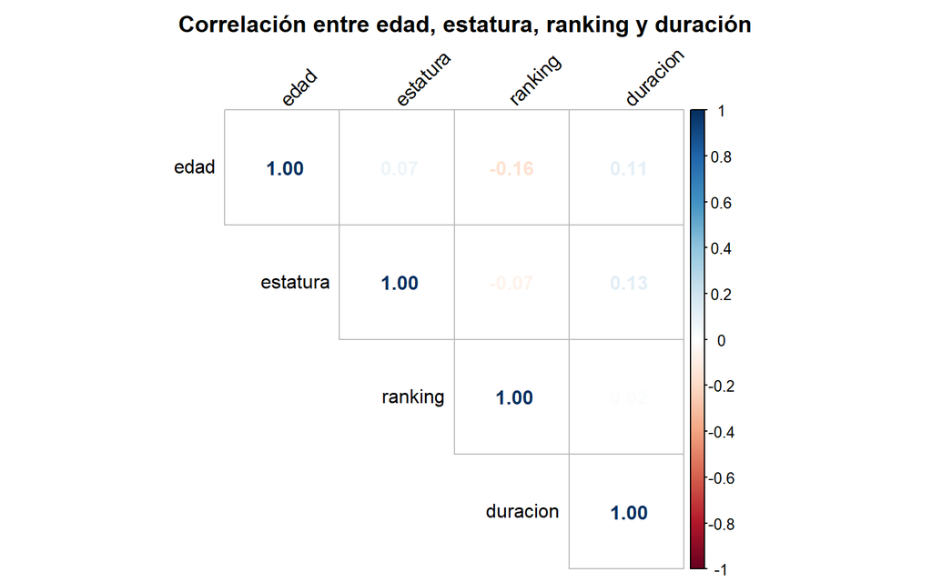

```r
corr_vars <- df %>%
  select(edad = w_p1_age, estatura = w_p1_hgt,
         ranking = w_rank_num, duracion = duration_min) %>%
  drop_na()

m <- cor(corr_vars)

corrplot(m, method = "number", type = "upper",
         tl.col = "black", tl.srt = 45,
         title = "Correlación entre edad, estatura, ranking y duración",
         mar = c(0, 0, 2, 0))
```

Las correlaciones son todas débiles (ninguna supera |0.16|): edad y ranking correlacionan levemente negativo (-0.161, jugadores más experimentados/mayores tienden a tener mejor ranking numérico, que es menor cuanto mejor eres), y estatura correlaciona muy débil con duración (0.127) y con edad (0.073). No hay evidencia de multicolinealidad entre estas variables — cada una aporta información relativamente independiente, así que ninguna sobra de cara al dashboard.

# 8 Bloque 8 — Estadísticas de juego y síntesis

## 8.1 Subconjunto con estadísticas completas

```r
stat_cols <- c("w_p1_tot_kills","w_p2_tot_kills","l_p1_tot_kills","l_p2_tot_kills",
               "w_p1_tot_aces","w_p2_tot_aces","l_p1_tot_aces","l_p2_tot_aces",
               "w_p1_tot_blocks","w_p2_tot_blocks","l_p1_tot_blocks","l_p2_tot_blocks",
               "w_p1_tot_digs","w_p2_tot_digs","l_p1_tot_digs","l_p2_tot_digs",
               "w_p1_tot_hitpct","l_p1_tot_hitpct")

df_stats <- df %>% drop_na(all_of(stat_cols))

nrow(df_stats)
```

```
## [1] 14561
```

```r
round(nrow(df_stats) / nrow(df) * 100, 2)
```

```
## [1] 18.97
```

```r
df_stats %>% count(circuit)
```

```
## # A tibble: 2 × 2
##   circuit     n
##   <fct>   <int>
## 1 AVP     13161
## 2 FIVB     1400
```

Solo **14.561 partidos (18.97%)** tienen estadísticas completas de juego — justo lo esperado tras confirmar en el Bloque 2 que ~80% son NA. De esos 14.561, **13.161 son de AVP y apenas 1.400 de FIVB**: confirma que esta sección del EDA describe mayoritariamente el circuito estadounidense, no el deporte en general, y así se debe aclarar en el dashboard.

## 8.2 Comparativa ganadores vs. perdedores (kills, aces, bloqueos, digs)

```r
df_long <- df_stats %>%
  transmute(
    kills_w = w_p1_tot_kills, kills_l = l_p1_tot_kills,
    aces_w = w_p1_tot_aces,  aces_l = l_p1_tot_aces,
    blocks_w = w_p1_tot_blocks, blocks_l = l_p1_tot_blocks,
    digs_w = w_p1_tot_digs, digs_l = l_p1_tot_digs
  ) %>%
  pivot_longer(everything(), names_to = c("estadistica", "resultado"),
               names_sep = "_", values_to = "valor") %>%
  mutate(resultado = recode(resultado, w = "Ganador", l = "Perdedor"),
         estadistica = recode(estadistica, kills = "Kills", aces = "Aces",
                               blocks = "Bloqueos", digs = "Digs"))

p_comp <- df_long %>%
  ggplot(aes(x = resultado, y = valor, fill = resultado)) +
  geom_violin(alpha = 0.6, trim = FALSE) +
  geom_boxplot(width = 0.15, fill = "white", outlier.shape = NA) +
  facet_wrap(~estadistica, scales = "free_y") +
  scale_fill_manual(values = c("Ganador" = "#1b9e77", "Perdedor" = "#d95f02")) +
  labs(title = "Kills, aces, bloqueos y digs: ganador vs. perdedor",
       subtitle = "Jugador en posición 1, partidos con estadísticas completas (n = 14.561)",
       x = NULL, y = "Valor", fill = NULL)

ggplotly(p_comp)
```

[interactive chart not shown]

En las cuatro estadísticas, el ganador supera al perdedor en promedio: kills (14.74 vs 12.79), aces (1.39 vs 0.82), bloqueos (1.75 vs 1.03) y digs (8.36 vs 7.20). La diferencia proporcionalmente más grande está en **bloqueos** (+70%) y **aces** (+69%), sugiriendo que estas dos jugadas — más que los kills, que es la más numerosa pero con menor diferencia relativa (+15%)— son las que más distinguen a un ganador de un perdedor.

## 8.3 Relación hitpct vs. kills

```r
p_bin2d <- df_stats %>%
  filter(w_p1_tot_hitpct > -1, w_p1_tot_hitpct < 1) %>%
  ggplot(aes(x = w_p1_tot_hitpct, y = w_p1_tot_kills)) +
  geom_bin2d(bins = 30) +
  scale_fill_viridis_c() +
  labs(title = "Relación entre porcentaje de ataque (hitpct) y kills",
       subtitle = "Jugadores ganadores, posición 1 — color = número de partidos en esa celda",
       x = "Hit % (w_p1_tot_hitpct)", y = "Kills (w_p1_tot_kills)", fill = "Partidos")

ggplotly(p_bin2d)
```

[interactive chart not shown]

La correlación entre `hitpct` y `kills` es positiva pero débil (r = 0.136): la mayor concentración de partidos está entre 0.3 y 0.6 de hitpct con entre 5 y 20 kills, sin que un hitpct más alto implique automáticamente más kills. Esto tiene sentido: hitpct mide *eficiencia* del ataque (buenos ataques menos errores, sobre el total de intentos), mientras que kills mide *volumen* — un jugador puede tener pocos intentos muy eficientes (hitpct alto, kills bajos) o muchos intentos con eficiencia media (hitpct medio, kills altos). Son dos dimensiones distintas del rendimiento de ataque, y el dashboard debería mostrarlas por separado en vez de asumir que una resume a la otra.